# Risk Factor Analysis

## Outcome Variable

**Outcome Variable:** ever_wasted

## Predictor Variables

**Intervention Variable:** perdiar6

**Adjustment Set:**

unadjusted

## Stratifying Variables

The analysis was stratified on these variable(s):

- agecat
- studyid
- country

## Data Summary

| agecat | studyid | country | perdiar6 | ever_wasted | n_cell | n |
| --- | --- | --- | --- | --- | --- | --- |
| 0-24 months (no birth wast) | ki0047075b-MAL-ED | BANGLADESH | (0%, 5%] | 0 | 75 | 261 |
| 0-24 months (no birth wast) | ki0047075b-MAL-ED | BANGLADESH | (0%, 5%] | 1 | 23 | 261 |
| 0-24 months (no birth wast) | ki0047075b-MAL-ED | BANGLADESH | 0% | 0 | 63 | 261 |
| 0-24 months (no birth wast) | ki0047075b-MAL-ED | BANGLADESH | 0% | 1 | 20 | 261 |
| 0-24 months (no birth wast) | ki0047075b-MAL-ED | BANGLADESH | >5% | 0 | 65 | 261 |
| 0-24 months (no birth wast) | ki0047075b-MAL-ED | BANGLADESH | >5% | 1 | 15 | 261 |
| 0-24 months (no birth wast) | ki0047075b-MAL-ED | BRAZIL | (0%, 5%] | 0 | 14 | 229 |
| 0-24 months (no birth wast) | ki0047075b-MAL-ED | BRAZIL | (0%, 5%] | 1 | 1 | 229 |
| 0-24 months (no birth wast) | ki0047075b-MAL-ED | BRAZIL | 0% | 0 | 202 | 229 |
| 0-24 months (no birth wast) | ki0047075b-MAL-ED | BRAZIL | 0% | 1 | 10 | 229 |
| 0-24 months (no birth wast) | ki0047075b-MAL-ED | BRAZIL | >5% | 0 | 1 | 229 |
| 0-24 months (no birth wast) | ki0047075b-MAL-ED | BRAZIL | >5% | 1 | 1 | 229 |
| 0-24 months (no birth wast) | ki0047075b-MAL-ED | INDIA | (0%, 5%] | 0 | 86 | 242 |
| 0-24 months (no birth wast) | ki0047075b-MAL-ED | INDIA | (0%, 5%] | 1 | 42 | 242 |
| 0-24 months (no birth wast) | ki0047075b-MAL-ED | INDIA | 0% | 0 | 32 | 242 |
| 0-24 months (no birth wast) | ki0047075b-MAL-ED | INDIA | 0% | 1 | 23 | 242 |
| 0-24 months (no birth wast) | ki0047075b-MAL-ED | INDIA | >5% | 0 | 35 | 242 |
| 0-24 months (no birth wast) | ki0047075b-MAL-ED | INDIA | >5% | 1 | 24 | 242 |
| 0-24 months (no birth wast) | ki0047075b-MAL-ED | NEPAL | (0%, 5%] | 0 | 63 | 238 |
| 0-24 months (no birth wast) | ki0047075b-MAL-ED | NEPAL | (0%, 5%] | 1 | 13 | 238 |
| 0-24 months (no birth wast) | ki0047075b-MAL-ED | NEPAL | 0% | 0 | 64 | 238 |
| 0-24 months (no birth wast) | ki0047075b-MAL-ED | NEPAL | 0% | 1 | 18 | 238 |
| 0-24 months (no birth wast) | ki0047075b-MAL-ED | NEPAL | >5% | 0 | 66 | 238 |
| 0-24 months (no birth wast) | ki0047075b-MAL-ED | NEPAL | >5% | 1 | 14 | 238 |
| 0-24 months (no birth wast) | ki0047075b-MAL-ED | PERU | (0%, 5%] | 0 | 88 | 299 |
| 0-24 months (no birth wast) | ki0047075b-MAL-ED | PERU | (0%, 5%] | 1 | 5 | 299 |
| 0-24 months (no birth wast) | ki0047075b-MAL-ED | PERU | 0% | 0 | 80 | 299 |
| 0-24 months (no birth wast) | ki0047075b-MAL-ED | PERU | 0% | 1 | 6 | 299 |
| 0-24 months (no birth wast) | ki0047075b-MAL-ED | PERU | >5% | 0 | 111 | 299 |
| 0-24 months (no birth wast) | ki0047075b-MAL-ED | PERU | >5% | 1 | 9 | 299 |

[output cut: 258 more lines]

The following strata were considered:

- agecat: 0-24 months (no birth wast), studyid: ki0047075b-MAL-ED, country: BANGLADESH
- agecat: 0-24 months (no birth wast), studyid: ki0047075b-MAL-ED, country: BRAZIL
- agecat: 0-24 months (no birth wast), studyid: ki0047075b-MAL-ED, country: INDIA
- agecat: 0-24 months (no birth wast), studyid: ki0047075b-MAL-ED, country: NEPAL
- agecat: 0-24 months (no birth wast), studyid: ki0047075b-MAL-ED, country: PERU
- agecat: 0-24 months (no birth wast), studyid: ki0047075b-MAL-ED, country: SOUTH AFRICA
- agecat: 0-24 months (no birth wast), studyid: ki0047075b-MAL-ED, country: TANZANIA, UNITED REPUBLIC OF
- agecat: 0-24 months (no birth wast), studyid: ki1000109-ResPak, country: PAKISTAN
- agecat: 0-24 months (no birth wast), studyid: ki1017093-NIH-Birth, country: BANGLADESH
- agecat: 0-24 months (no birth wast), studyid: ki1017093b-PROVIDE, country: BANGLADESH
- agecat: 0-24 months (no birth wast), studyid: ki1017093c-NIH-Crypto, country: BANGLADESH
- agecat: 0-24 months (no birth wast), studyid: ki1114097-CMIN, country: BANGLADESH
- agecat: 0-24 months (no birth wast), studyid: ki1114097-CMIN, country: BRAZIL
- agecat: 0-24 months (no birth wast), studyid: ki1114097-CMIN, country: GUINEA-BISSAU
- agecat: 0-24 months (no birth wast), studyid: ki1114097-CMIN, country: PERU
- agecat: 0-24 months (no birth wast), studyid: ki1114097-CONTENT, country: PERU
- agecat: 0-6 months (no birth wast), studyid: ki0047075b-MAL-ED, country: BANGLADESH
- agecat: 0-6 months (no birth wast), studyid: ki0047075b-MAL-ED, country: BRAZIL
- agecat: 0-6 months (no birth wast), studyid: ki0047075b-MAL-ED, country: INDIA
- agecat: 0-6 months (no birth wast), studyid: ki0047075b-MAL-ED, country: NEPAL
- agecat: 0-6 months (no birth wast), studyid: ki0047075b-MAL-ED, country: PERU
- agecat: 0-6 months (no birth wast), studyid: ki0047075b-MAL-ED, country: SOUTH AFRICA
- agecat: 0-6 months (no birth wast), studyid: ki0047075b-MAL-ED, country: TANZANIA, UNITED REPUBLIC OF
- agecat: 0-6 months (no birth wast), studyid: ki1000109-ResPak, country: PAKISTAN
- agecat: 0-6 months (no birth wast), studyid: ki1017093-NIH-Birth, country: BANGLADESH
- agecat: 0-6 months (no birth wast), studyid: ki1017093b-PROVIDE, country: BANGLADESH
- agecat: 0-6 months (no birth wast), studyid: ki1017093c-NIH-Crypto, country: BANGLADESH
- agecat: 0-6 months (no birth wast), studyid: ki1114097-CMIN, country: BANGLADESH
- agecat: 0-6 months (no birth wast), studyid: ki1114097-CMIN, country: BRAZIL
- agecat: 0-6 months (no birth wast), studyid: ki1114097-CMIN, country: GUINEA-BISSAU
- agecat: 0-6 months (no birth wast), studyid: ki1114097-CMIN, country: PERU
- agecat: 0-6 months (no birth wast), studyid: ki1114097-CONTENT, country: PERU
- agecat: 6-24 months, studyid: ki0047075b-MAL-ED, country: BANGLADESH
- agecat: 6-24 months, studyid: ki0047075b-MAL-ED, country: BRAZIL
- agecat: 6-24 months, studyid: ki0047075b-MAL-ED, country: INDIA
- agecat: 6-24 months, studyid: ki0047075b-MAL-ED, country: NEPAL
- agecat: 6-24 months, studyid: ki0047075b-MAL-ED, country: PERU
- agecat: 6-24 months, studyid: ki0047075b-MAL-ED, country: SOUTH AFRICA
- agecat: 6-24 months, studyid: ki0047075b-MAL-ED, country: TANZANIA, UNITED REPUBLIC OF
- agecat: 6-24 months, studyid: ki1000109-ResPak, country: PAKISTAN
- agecat: 6-24 months, studyid: ki1017093-NIH-Birth, country: BANGLADESH
- agecat: 6-24 months, studyid: ki1017093b-PROVIDE, country: BANGLADESH
- agecat: 6-24 months, studyid: ki1017093c-NIH-Crypto, country: BANGLADESH
- agecat: 6-24 months, studyid: ki1114097-CMIN, country: BANGLADESH
- agecat: 6-24 months, studyid: ki1114097-CMIN, country: BRAZIL
- agecat: 6-24 months, studyid: ki1114097-CMIN, country: GUINEA-BISSAU
- agecat: 6-24 months, studyid: ki1114097-CMIN, country: PERU
- agecat: 6-24 months, studyid: ki1114097-CONTENT, country: PERU

### Dropped Strata

Some strata were dropped due to rare outcomes:

- agecat: 0-24 months (no birth wast), studyid: ki0047075b-MAL-ED, country: BRAZIL
- agecat: 0-24 months (no birth wast), studyid: ki0047075b-MAL-ED, country: SOUTH AFRICA
- agecat: 0-24 months (no birth wast), studyid: ki0047075b-MAL-ED, country: TANZANIA, UNITED REPUBLIC OF
- agecat: 0-24 months (no birth wast), studyid: ki1114097-CMIN, country: BRAZIL
- agecat: 0-24 months (no birth wast), studyid: ki1114097-CONTENT, country: PERU
- agecat: 0-6 months (no birth wast), studyid: ki0047075b-MAL-ED, country: BRAZIL
- agecat: 0-6 months (no birth wast), studyid: ki0047075b-MAL-ED, country: NEPAL
- agecat: 0-6 months (no birth wast), studyid: ki0047075b-MAL-ED, country: PERU
- agecat: 0-6 months (no birth wast), studyid: ki0047075b-MAL-ED, country: SOUTH AFRICA
- agecat: 0-6 months (no birth wast), studyid: ki0047075b-MAL-ED, country: TANZANIA, UNITED REPUBLIC OF
- agecat: 0-6 months (no birth wast), studyid: ki1114097-CMIN, country: BRAZIL
- agecat: 0-6 months (no birth wast), studyid: ki1114097-CMIN, country: GUINEA-BISSAU
- agecat: 0-6 months (no birth wast), studyid: ki1114097-CMIN, country: PERU
- agecat: 0-6 months (no birth wast), studyid: ki1114097-CONTENT, country: PERU
- agecat: 6-24 months, studyid: ki0047075b-MAL-ED, country: BRAZIL
- agecat: 6-24 months, studyid: ki0047075b-MAL-ED, country: PERU
- agecat: 6-24 months, studyid: ki0047075b-MAL-ED, country: SOUTH AFRICA
- agecat: 6-24 months, studyid: ki0047075b-MAL-ED, country: TANZANIA, UNITED REPUBLIC OF
- agecat: 6-24 months, studyid: ki1114097-CMIN, country: BRAZIL
- agecat: 6-24 months, studyid: ki1114097-CONTENT, country: PERU

## Methods Detail

We’re interested in the causal parameters $E[Y_a]$ for all values of $a \in \mathcal{A}$. These parameters represent the mean outcome if, possibly contrary to fact, we intervened to set all units to have $A=a$. Under the randomization and positivity assumptions, these are identified by the statistical parameters $\psi_a=E_W[E_{Y|A,W}(Y|A=a,W)]$. In addition, we’re interested in the mean of $Y$, $E[Y]$ under no intervention (the observed mean). We will estimate these parameters by using SuperLearner to fit the relevant likelihood factors – $E_{Y|A,W}(Y|A=a,W)$ and $p(A=a|W)$, and then updating our likelihood fit using a joint TMLE.

For unadjusted analyses ($W=\{\}$), initial likelihoods were estimated using Lrnr_glm to estimate the simple $E(Y|A)$ and Lrnr_mean to estimate $p(A)$. For adjusted analyses, a small library containing Lrnr_glmnet, Lrnr_xgboost, and Lrnr_mean was used.

Having estimated these parameters, we will then use the delta method to estimate relative risks and attributable risks relative to a prespecified baseline level of $A$.

# Results Detail

## Results Plots

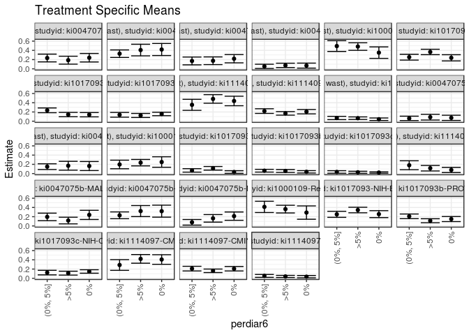

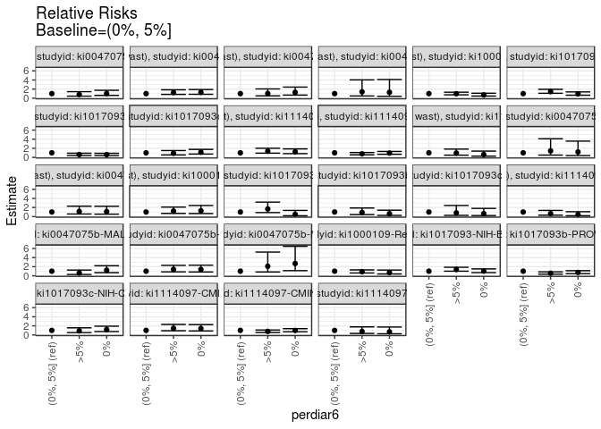

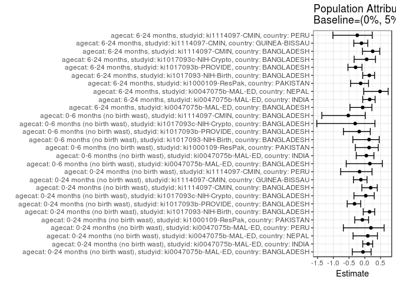

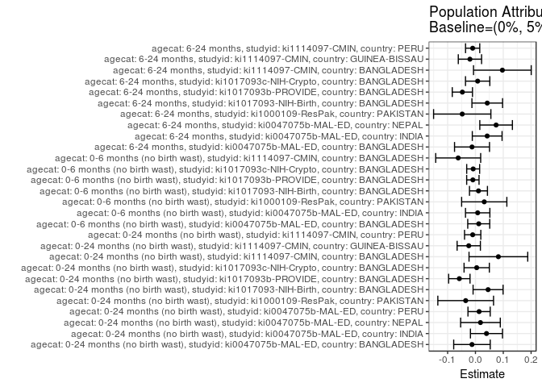

## Results Table

### Parameter: TSM

| agecat | studyid | country | intervention_level | baseline_level | estimate | ci_lower | ci_upper |
| --- | --- | --- | --- | --- | --- | --- | --- |
| 0-24 months (no birth wast) | ki0047075b-MAL-ED | BANGLADESH | (0%, 5%] | NA | 0.2346939 | 0.1506246 | 0.3187631 |
| 0-24 months (no birth wast) | ki0047075b-MAL-ED | BANGLADESH | 0% | NA | 0.2409639 | 0.1487811 | 0.3331466 |
| 0-24 months (no birth wast) | ki0047075b-MAL-ED | BANGLADESH | >5% | NA | 0.1875000 | 0.1018063 | 0.2731937 |
| 0-24 months (no birth wast) | ki0047075b-MAL-ED | INDIA | (0%, 5%] | NA | 0.3281250 | 0.2466159 | 0.4096341 |
| 0-24 months (no birth wast) | ki0047075b-MAL-ED | INDIA | 0% | NA | 0.4181818 | 0.2875521 | 0.5488116 |
| 0-24 months (no birth wast) | ki0047075b-MAL-ED | INDIA | >5% | NA | 0.4067797 | 0.2811741 | 0.5323852 |
| 0-24 months (no birth wast) | ki0047075b-MAL-ED | NEPAL | (0%, 5%] | NA | 0.1710526 | 0.0862159 | 0.2558894 |
| 0-24 months (no birth wast) | ki0047075b-MAL-ED | NEPAL | 0% | NA | 0.2195122 | 0.1297346 | 0.3092898 |
| 0-24 months (no birth wast) | ki0047075b-MAL-ED | NEPAL | >5% | NA | 0.1750000 | 0.0915621 | 0.2584379 |
| 0-24 months (no birth wast) | ki0047075b-MAL-ED | PERU | (0%, 5%] | NA | 0.0537634 | 0.0078460 | 0.0996809 |
| 0-24 months (no birth wast) | ki0047075b-MAL-ED | PERU | 0% | NA | 0.0697674 | 0.0158352 | 0.1236997 |
| 0-24 months (no birth wast) | ki0047075b-MAL-ED | PERU | >5% | NA | 0.0750000 | 0.0277952 | 0.1222048 |
| 0-24 months (no birth wast) | ki1000109-ResPak | PAKISTAN | (0%, 5%] | NA | 0.4929577 | 0.3764532 | 0.6094622 |
| 0-24 months (no birth wast) | ki1000109-ResPak | PAKISTAN | 0% | NA | 0.3508772 | 0.2267553 | 0.4749991 |
| 0-24 months (no birth wast) | ki1000109-ResPak | PAKISTAN | >5% | NA | 0.4827586 | 0.4012746 | 0.5642427 |
| 0-24 months (no birth wast) | ki1017093-NIH-Birth | BANGLADESH | (0%, 5%] | NA | 0.2527473 | 0.1895565 | 0.3159380 |
| 0-24 months (no birth wast) | ki1017093-NIH-Birth | BANGLADESH | 0% | NA | 0.2387097 | 0.1715426 | 0.3058768 |
| 0-24 months (no birth wast) | ki1017093-NIH-Birth | BANGLADESH | >5% | NA | 0.3653846 | 0.3068037 | 0.4239655 |
| 0-24 months (no birth wast) | ki1017093b-PROVIDE | BANGLADESH | (0%, 5%] | NA | 0.2355212 | 0.1838067 | 0.2872357 |
| 0-24 months (no birth wast) | ki1017093b-PROVIDE | BANGLADESH | 0% | NA | 0.1408451 | 0.0940951 | 0.1875950 |
| 0-24 months (no birth wast) | ki1017093b-PROVIDE | BANGLADESH | >5% | NA | 0.1441860 | 0.0971970 | 0.1911751 |
| 0-24 months (no birth wast) | ki1017093c-NIH-Crypto | BANGLADESH | (0%, 5%] | NA | 0.1387283 | 0.0871858 | 0.1902709 |
| 0-24 months (no birth wast) | ki1017093c-NIH-Crypto | BANGLADESH | 0% | NA | 0.1565934 | 0.1192348 | 0.1939520 |
| 0-24 months (no birth wast) | ki1017093c-NIH-Crypto | BANGLADESH | >5% | NA | 0.1244240 | 0.0804794 | 0.1683685 |
| 0-24 months (no birth wast) | ki1114097-CMIN | BANGLADESH | (0%, 5%] | NA | 0.3548387 | 0.2355143 | 0.4741631 |
| 0-24 months (no birth wast) | ki1114097-CMIN | BANGLADESH | 0% | NA | 0.4382022 | 0.3349243 | 0.5414802 |
| 0-24 months (no birth wast) | ki1114097-CMIN | BANGLADESH | >5% | NA | 0.4821429 | 0.3894259 | 0.5748598 |
| 0-24 months (no birth wast) | ki1114097-CMIN | GUINEA-BISSAU | (0%, 5%] | NA | 0.2192308 | 0.1689141 | 0.2695474 |
| 0-24 months (no birth wast) | ki1114097-CMIN | GUINEA-BISSAU | 0% | NA | 0.2064057 | 0.1590586 | 0.2537528 |
| 0-24 months (no birth wast) | ki1114097-CMIN | GUINEA-BISSAU | >5% | NA | 0.1698113 | 0.1315842 | 0.2080384 |

[output cut: 54 more lines]

### Parameter: E(Y)

| agecat | studyid | country | intervention_level | baseline_level | estimate | ci_lower | ci_upper |
| --- | --- | --- | --- | --- | --- | --- | --- |
| 0-24 months (no birth wast) | ki0047075b-MAL-ED | BANGLADESH | NA | NA | 0.2222222 | 0.1716883 | 0.2727561 |
| 0-24 months (no birth wast) | ki0047075b-MAL-ED | INDIA | NA | NA | 0.3677686 | 0.3068900 | 0.4286472 |
| 0-24 months (no birth wast) | ki0047075b-MAL-ED | NEPAL | NA | NA | 0.1890756 | 0.1392237 | 0.2389275 |
| 0-24 months (no birth wast) | ki0047075b-MAL-ED | PERU | NA | NA | 0.0668896 | 0.0385244 | 0.0952548 |
| 0-24 months (no birth wast) | ki1000109-ResPak | PAKISTAN | NA | NA | 0.4578755 | 0.3986666 | 0.5170843 |
| 0-24 months (no birth wast) | ki1017093-NIH-Birth | BANGLADESH | NA | NA | 0.2981575 | 0.2614320 | 0.3348829 |
| 0-24 months (no birth wast) | ki1017093b-PROVIDE | BANGLADESH | NA | NA | 0.1775837 | 0.1489858 | 0.2061816 |
| 0-24 months (no birth wast) | ki1017093c-NIH-Crypto | BANGLADESH | NA | NA | 0.1432361 | 0.1182149 | 0.1682572 |
| 0-24 months (no birth wast) | ki1114097-CMIN | BANGLADESH | NA | NA | 0.4372624 | 0.3771974 | 0.4973274 |
| 0-24 months (no birth wast) | ki1114097-CMIN | GUINEA-BISSAU | NA | NA | 0.1951754 | 0.1694388 | 0.2209121 |
| 0-24 months (no birth wast) | ki1114097-CMIN | PERU | NA | NA | 0.0600559 | 0.0426409 | 0.0774709 |
| 0-6 months (no birth wast) | ki0047075b-MAL-ED | BANGLADESH | NA | NA | 0.0730769 | 0.0413805 | 0.1047733 |
| 0-6 months (no birth wast) | ki0047075b-MAL-ED | INDIA | NA | NA | 0.1576763 | 0.1115695 | 0.2037832 |
| 0-6 months (no birth wast) | ki1000109-ResPak | PAKISTAN | NA | NA | 0.2287823 | 0.1786790 | 0.2788855 |
| 0-6 months (no birth wast) | ki1017093-NIH-Birth | BANGLADESH | NA | NA | 0.0794473 | 0.0574004 | 0.1014943 |
| 0-6 months (no birth wast) | ki1017093b-PROVIDE | BANGLADESH | NA | NA | 0.0527086 | 0.0359384 | 0.0694789 |
| 0-6 months (no birth wast) | ki1017093c-NIH-Crypto | BANGLADESH | NA | NA | 0.0267023 | 0.0151493 | 0.0382553 |
| 0-6 months (no birth wast) | ki1114097-CMIN | BANGLADESH | NA | NA | 0.1183206 | 0.0791362 | 0.1575050 |
| 6-24 months | ki0047075b-MAL-ED | BANGLADESH | NA | NA | 0.1833333 | 0.1342773 | 0.2323893 |
| 6-24 months | ki0047075b-MAL-ED | INDIA | NA | NA | 0.2723404 | 0.2153029 | 0.3293779 |
| 6-24 months | ki0047075b-MAL-ED | NEPAL | NA | NA | 0.1531915 | 0.1070438 | 0.1993392 |
| 6-24 months | ki1000109-ResPak | PAKISTAN | NA | NA | 0.3652174 | 0.3028556 | 0.4275792 |
| 6-24 months | ki1017093-NIH-Birth | BANGLADESH | NA | NA | 0.2939002 | 0.2554778 | 0.3323226 |
| 6-24 months | ki1017093b-PROVIDE | BANGLADESH | NA | NA | 0.1609756 | 0.1319065 | 0.1900447 |
| 6-24 months | ki1017093c-NIH-Crypto | BANGLADESH | NA | NA | 0.1315068 | 0.1069744 | 0.1560393 |
| 6-24 months | ki1114097-CMIN | BANGLADESH | NA | NA | 0.3849206 | 0.3247254 | 0.4451159 |
| 6-24 months | ki1114097-CMIN | GUINEA-BISSAU | NA | NA | 0.1896745 | 0.1639180 | 0.2154311 |
| 6-24 months | ki1114097-CMIN | PERU | NA | NA | 0.0420420 | 0.0267891 | 0.0572949 |

### Parameter: RR

| agecat | studyid | country | intervention_level | baseline_level | estimate | ci_lower | ci_upper |
| --- | --- | --- | --- | --- | --- | --- | --- |
| 0-24 months (no birth wast) | ki0047075b-MAL-ED | BANGLADESH | (0%, 5%] | (0%, 5%] | 1.0000000 | 1.0000000 | 1.0000000 |
| 0-24 months (no birth wast) | ki0047075b-MAL-ED | BANGLADESH | 0% | (0%, 5%] | 1.0267156 | 0.6079157 | 1.7340313 |
| 0-24 months (no birth wast) | ki0047075b-MAL-ED | BANGLADESH | >5% | (0%, 5%] | 0.7989130 | 0.4470049 | 1.4278638 |
| 0-24 months (no birth wast) | ki0047075b-MAL-ED | INDIA | (0%, 5%] | (0%, 5%] | 1.0000000 | 1.0000000 | 1.0000000 |
| 0-24 months (no birth wast) | ki0047075b-MAL-ED | INDIA | 0% | (0%, 5%] | 1.2744589 | 0.8550597 | 1.8995697 |
| 0-24 months (no birth wast) | ki0047075b-MAL-ED | INDIA | >5% | (0%, 5%] | 1.2397094 | 0.8340841 | 1.8425954 |
| 0-24 months (no birth wast) | ki0047075b-MAL-ED | NEPAL | (0%, 5%] | (0%, 5%] | 1.0000000 | 1.0000000 | 1.0000000 |
| 0-24 months (no birth wast) | ki0047075b-MAL-ED | NEPAL | 0% | (0%, 5%] | 1.2833021 | 0.6747503 | 2.4407018 |
| 0-24 months (no birth wast) | ki0047075b-MAL-ED | NEPAL | >5% | (0%, 5%] | 1.0230769 | 0.5141903 | 2.0356012 |
| 0-24 months (no birth wast) | ki0047075b-MAL-ED | PERU | (0%, 5%] | (0%, 5%] | 1.0000000 | 1.0000000 | 1.0000000 |
| 0-24 months (no birth wast) | ki0047075b-MAL-ED | PERU | 0% | (0%, 5%] | 1.2976744 | 0.4100892 | 4.1063236 |
| 0-24 months (no birth wast) | ki0047075b-MAL-ED | PERU | >5% | (0%, 5%] | 1.3950000 | 0.4828579 | 4.0302231 |
| 0-24 months (no birth wast) | ki1000109-ResPak | PAKISTAN | (0%, 5%] | (0%, 5%] | 1.0000000 | 1.0000000 | 1.0000000 |
| 0-24 months (no birth wast) | ki1000109-ResPak | PAKISTAN | 0% | (0%, 5%] | 0.7117794 | 0.4651387 | 1.0892020 |
| 0-24 months (no birth wast) | ki1000109-ResPak | PAKISTAN | >5% | (0%, 5%] | 0.9793103 | 0.7324730 | 1.3093299 |
| 0-24 months (no birth wast) | ki1017093-NIH-Birth | BANGLADESH | (0%, 5%] | (0%, 5%] | 1.0000000 | 1.0000000 | 1.0000000 |
| 0-24 months (no birth wast) | ki1017093-NIH-Birth | BANGLADESH | 0% | (0%, 5%] | 0.9444600 | 0.6482065 | 1.3761120 |
| 0-24 months (no birth wast) | ki1017093-NIH-Birth | BANGLADESH | >5% | (0%, 5%] | 1.4456522 | 1.0741771 | 1.9455919 |
| 0-24 months (no birth wast) | ki1017093b-PROVIDE | BANGLADESH | (0%, 5%] | (0%, 5%] | 1.0000000 | 1.0000000 | 1.0000000 |
| 0-24 months (no birth wast) | ki1017093b-PROVIDE | BANGLADESH | 0% | (0%, 5%] | 0.5980143 | 0.4016721 | 0.8903310 |
| 0-24 months (no birth wast) | ki1017093b-PROVIDE | BANGLADESH | >5% | (0%, 5%] | 0.6121998 | 0.4132685 | 0.9068887 |
| 0-24 months (no birth wast) | ki1017093c-NIH-Crypto | BANGLADESH | (0%, 5%] | (0%, 5%] | 1.0000000 | 1.0000000 | 1.0000000 |
| 0-24 months (no birth wast) | ki1017093c-NIH-Crypto | BANGLADESH | 0% | (0%, 5%] | 1.1287775 | 0.7258573 | 1.7553569 |
| 0-24 months (no birth wast) | ki1017093c-NIH-Crypto | BANGLADESH | >5% | (0%, 5%] | 0.8968894 | 0.5371695 | 1.4974985 |
| 0-24 months (no birth wast) | ki1114097-CMIN | BANGLADESH | (0%, 5%] | (0%, 5%] | 1.0000000 | 1.0000000 | 1.0000000 |
| 0-24 months (no birth wast) | ki1114097-CMIN | BANGLADESH | 0% | (0%, 5%] | 1.2349336 | 0.8190344 | 1.8620230 |
| 0-24 months (no birth wast) | ki1114097-CMIN | BANGLADESH | >5% | (0%, 5%] | 1.3587662 | 0.9223761 | 2.0016191 |
| 0-24 months (no birth wast) | ki1114097-CMIN | GUINEA-BISSAU | (0%, 5%] | (0%, 5%] | 1.0000000 | 1.0000000 | 1.0000000 |
| 0-24 months (no birth wast) | ki1114097-CMIN | GUINEA-BISSAU | 0% | (0%, 5%] | 0.9414997 | 0.6806039 | 1.3024045 |
| 0-24 months (no birth wast) | ki1114097-CMIN | GUINEA-BISSAU | >5% | (0%, 5%] | 0.7745780 | 0.5616234 | 1.0682798 |

[output cut: 54 more lines]

### Parameter: PAR

| agecat | studyid | country | intervention_level | baseline_level | estimate | ci_lower | ci_upper |
| --- | --- | --- | --- | --- | --- | --- | --- |
| 0-24 months (no birth wast) | ki0047075b-MAL-ED | BANGLADESH | (0%, 5%] | NA | -0.0124717 | -0.0781513 | 0.0532080 |
| 0-24 months (no birth wast) | ki0047075b-MAL-ED | INDIA | (0%, 5%] | NA | 0.0396436 | -0.0179920 | 0.0972792 |
| 0-24 months (no birth wast) | ki0047075b-MAL-ED | NEPAL | (0%, 5%] | NA | 0.0180230 | -0.0532926 | 0.0893386 |
| 0-24 months (no birth wast) | ki0047075b-MAL-ED | PERU | (0%, 5%] | NA | 0.0131262 | -0.0268914 | 0.0531438 |
| 0-24 months (no birth wast) | ki1000109-ResPak | PAKISTAN | (0%, 5%] | NA | -0.0350823 | -0.1351767 | 0.0650121 |
| 0-24 months (no birth wast) | ki1017093-NIH-Birth | BANGLADESH | (0%, 5%] | NA | 0.0454102 | -0.0085082 | 0.0993286 |
| 0-24 months (no birth wast) | ki1017093b-PROVIDE | BANGLADESH | (0%, 5%] | NA | -0.0579375 | -0.0963528 | -0.0195223 |
| 0-24 months (no birth wast) | ki1017093c-NIH-Crypto | BANGLADESH | (0%, 5%] | NA | 0.0045078 | -0.0409191 | 0.0499346 |
| 0-24 months (no birth wast) | ki1114097-CMIN | BANGLADESH | (0%, 5%] | NA | 0.0824236 | -0.0230893 | 0.1879366 |
| 0-24 months (no birth wast) | ki1114097-CMIN | GUINEA-BISSAU | (0%, 5%] | NA | -0.0240553 | -0.0658954 | 0.0177847 |
| 0-24 months (no birth wast) | ki1114097-CMIN | PERU | (0%, 5%] | NA | -0.0099441 | -0.0392000 | 0.0193117 |
| 0-6 months (no birth wast) | ki0047075b-MAL-ED | BANGLADESH | (0%, 5%] | NA | 0.0118524 | -0.0276619 | 0.0513668 |
| 0-6 months (no birth wast) | ki0047075b-MAL-ED | INDIA | (0%, 5%] | NA | 0.0080700 | -0.0357180 | 0.0518581 |
| 0-6 months (no birth wast) | ki1000109-ResPak | PAKISTAN | (0%, 5%] | NA | 0.0315992 | -0.0496564 | 0.1128548 |
| 0-6 months (no birth wast) | ki1017093-NIH-Birth | BANGLADESH | (0%, 5%] | NA | 0.0108759 | -0.0213969 | 0.0431487 |
| 0-6 months (no birth wast) | ki1017093b-PROVIDE | BANGLADESH | (0%, 5%] | NA | -0.0093069 | -0.0315177 | 0.0129040 |
| 0-6 months (no birth wast) | ki1017093c-NIH-Crypto | BANGLADESH | (0%, 5%] | NA | -0.0081815 | -0.0314321 | 0.0150692 |
| 0-6 months (no birth wast) | ki1114097-CMIN | BANGLADESH | (0%, 5%] | NA | -0.0620073 | -0.1428056 | 0.0187910 |
| 6-24 months | ki0047075b-MAL-ED | BANGLADESH | (0%, 5%] | NA | -0.0123188 | -0.0751373 | 0.0504996 |
| 6-24 months | ki0047075b-MAL-ED | INDIA | (0%, 5%] | NA | 0.0421817 | -0.0113050 | 0.0956683 |
| 6-24 months | ki0047075b-MAL-ED | NEPAL | (0%, 5%] | NA | 0.0742441 | 0.0156499 | 0.1328383 |
| 6-24 months | ki1000109-ResPak | PAKISTAN | (0%, 5%] | NA | -0.0474810 | -0.1504418 | 0.0554798 |
| 6-24 months | ki1017093-NIH-Birth | BANGLADESH | (0%, 5%] | NA | 0.0424382 | -0.0126486 | 0.0975250 |
| 6-24 months | ki1017093b-PROVIDE | BANGLADESH | (0%, 5%] | NA | -0.0470244 | -0.0833440 | -0.0107048 |
| 6-24 months | ki1017093c-NIH-Crypto | BANGLADESH | (0%, 5%] | NA | 0.0079774 | -0.0357341 | 0.0516890 |
| 6-24 months | ki1114097-CMIN | BANGLADESH | (0%, 5%] | NA | 0.0967850 | -0.0069123 | 0.2004824 |
| 6-24 months | ki1114097-CMIN | GUINEA-BISSAU | (0%, 5%] | NA | -0.0198116 | -0.0616578 | 0.0220346 |
| 6-24 months | ki1114097-CMIN | PERU | (0%, 5%] | NA | -0.0100413 | -0.0355664 | 0.0154838 |

### Parameter: PAF

| agecat | studyid | country | intervention_level | baseline_level | estimate | ci_lower | ci_upper |
| --- | --- | --- | --- | --- | --- | --- | --- |
| 0-24 months (no birth wast) | ki0047075b-MAL-ED | BANGLADESH | (0%, 5%] | NA | -0.0561224 | -0.3970363 | 0.2015994 |
| 0-24 months (no birth wast) | ki0047075b-MAL-ED | INDIA | (0%, 5%] | NA | 0.1077949 | -0.0635743 | 0.2515522 |
| 0-24 months (no birth wast) | ki0047075b-MAL-ED | NEPAL | (0%, 5%] | NA | 0.0953216 | -0.3719190 | 0.4034320 |
| 0-24 months (no birth wast) | ki0047075b-MAL-ED | PERU | (0%, 5%] | NA | 0.1962366 | -0.6811512 | 0.6157183 |
| 0-24 months (no birth wast) | ki1000109-ResPak | PAKISTAN | (0%, 5%] | NA | -0.0766197 | -0.3192264 | 0.1213714 |
| 0-24 months (no birth wast) | ki1017093-NIH-Birth | BANGLADESH | (0%, 5%] | NA | 0.1523028 | -0.0489360 | 0.3149338 |
| 0-24 months (no birth wast) | ki1017093b-PROVIDE | BANGLADESH | (0%, 5%] | NA | -0.3262548 | -0.5579920 | -0.1289865 |
| 0-24 months (no birth wast) | ki1017093c-NIH-Crypto | BANGLADESH | (0%, 5%] | NA | 0.0314708 | -0.3437203 | 0.3019017 |
| 0-24 months (no birth wast) | ki1114097-CMIN | BANGLADESH | (0%, 5%] | NA | 0.1884993 | -0.0930057 | 0.3975023 |
| 0-24 months (no birth wast) | ki1114097-CMIN | GUINEA-BISSAU | (0%, 5%] | NA | -0.1232498 | -0.3591040 | 0.0716751 |
| 0-24 months (no birth wast) | ki1114097-CMIN | PERU | (0%, 5%] | NA | -0.1655814 | -0.7672583 | 0.2312499 |
| 0-6 months (no birth wast) | ki0047075b-MAL-ED | BANGLADESH | (0%, 5%] | NA | 0.1621912 | -0.5899101 | 0.5585137 |
| 0-6 months (no birth wast) | ki0047075b-MAL-ED | INDIA | (0%, 5%] | NA | 0.0511811 | -0.2710928 | 0.2917454 |
| 0-6 months (no birth wast) | ki1000109-ResPak | PAKISTAN | (0%, 5%] | NA | 0.1381190 | -0.3004533 | 0.4287847 |
| 0-6 months (no birth wast) | ki1017093-NIH-Birth | BANGLADESH | (0%, 5%] | NA | 0.1368944 | -0.3794326 | 0.4599582 |
| 0-6 months (no birth wast) | ki1017093b-PROVIDE | BANGLADESH | (0%, 5%] | NA | -0.1765719 | -0.6786305 | 0.1753269 |
| 0-6 months (no birth wast) | ki1017093c-NIH-Crypto | BANGLADESH | (0%, 5%] | NA | -0.3063953 | -1.5258573 | 0.3243210 |
| 0-6 months (no birth wast) | ki1114097-CMIN | BANGLADESH | (0%, 5%] | NA | -0.5240613 | -1.3650692 | 0.0178879 |
| 6-24 months | ki0047075b-MAL-ED | BANGLADESH | (0%, 5%] | NA | -0.0671937 | -0.4708999 | 0.2257105 |
| 6-24 months | ki0047075b-MAL-ED | INDIA | (0%, 5%] | NA | 0.1548859 | -0.0649620 | 0.3293490 |
| 6-24 months | ki0047075b-MAL-ED | NEPAL | (0%, 5%] | NA | 0.4846491 | -0.0344946 | 0.7432693 |
| 6-24 months | ki1000109-ResPak | PAKISTAN | (0%, 5%] | NA | -0.1300076 | -0.4505436 | 0.1196975 |
| 6-24 months | ki1017093-NIH-Birth | BANGLADESH | (0%, 5%] | NA | 0.1443966 | -0.0648117 | 0.3125008 |
| 6-24 months | ki1017093b-PROVIDE | BANGLADESH | (0%, 5%] | NA | -0.2921212 | -0.5349162 | -0.0877319 |
| 6-24 months | ki1017093c-NIH-Crypto | BANGLADESH | (0%, 5%] | NA | 0.0606618 | -0.3379372 | 0.3405099 |
| 6-24 months | ki1114097-CMIN | BANGLADESH | (0%, 5%] | NA | 0.2514416 | -0.0725542 | 0.4775651 |
| 6-24 months | ki1114097-CMIN | GUINEA-BISSAU | (0%, 5%] | NA | -0.1044507 | -0.3483816 | 0.0953514 |
| 6-24 months | ki1114097-CMIN | PERU | (0%, 5%] | NA | -0.2388393 | -1.0133269 | 0.2377180 |